# The N170 Response to Faces and Cars: An ERP CORE Analysis Report

Author

Marcus Skurray

Published

November 6, 2026

## Setup

```python
# Specify the required imports for your analysis
from pathlib import Path

from mini_mne import SimpleRaw, SimpleEpoch, grand_average, plot_evokeds

# Note how we can import a custom preprocessing function from a local script
from scripts.preproc import preprocess
```

```python
# Specify the required paths for your analysis
# Note that we now include a folder for saving preprocessed data
RAW_PATH = Path("data/raw")
PROCESSED_PATH = Path("data/processed")
```

## Introduction

The N170 is a negative-going event related potential (ERP) component measured using electroencephalography (EEG), beginning around 130 ms with a typical peak latency of approximately 170 ms following stimulus onset (Cashon and Holt 2015; Prieto et al. 2011). The N170 is commonly referred to as a face-sensitive response, eliciting a larger negative deflection in wave amplitudes to faces than non-face objects (Eimer 2011). The N170’s topography is most apparent over lateral posterior occipito-temporal scalp regions, and commonly exhibits right hemispheric lateralisation, with greater amplitudes over the right hemisphere than left (Deng et al. 2025; Kropotov 2016; Prieto et al. 2011). This rightward bias may reflect the broader organisation of cortical face-processing networks, with neuroimaging evidence implicating the right fusiform face area in facial processing, while the left fusiform regions are associated with visual word-form processing (Prieto et al. 2011; Vékony and Csifcsák 2017).

Srebro (1985) initially linked early EEG responses to facial perception, later explored by Bötzel et al. (1995) who identified prominent negative peaks at posterior-temporal electrodes at approximately 175 ms following face presentation. Dipole source localisation suggested that face perception may involve distributed sequential activation of occipital, lateral temporal and mesio-temporal brain structures. Bentin et al. (1996) provided greater detail, reporting a negative potential latency of 172 ms, termed the N170. The response to facial stimuli was largest over posterior-temporal regions, particularly in the right hemisphere. Furthermore, isolated eyes elicited a larger N170 than whole faces, while isolated lips or noses elicited smaller ERP responses, suggesting the N170 may be modulated by specific facial features rather than the whole face alone. Bentin et al.’s (1996) findings suggest the N170 reflects early detection and structural encoding of faces rather than facial identity recognition. Expanding on Bötzel et al.’s (1995) earlier source-localisation findings, Gao et al. (2019) utilised high-density ERP source localisation and fMRI, identifying the middle and posterior fusiform gyri as primary neural sources of the face-sensitive N170.

Continuing Bentin et al.’s (1996) early structural interpretations, the N170 is commonly associated with early configural face processing, particularly the spatial relationship and configuration of facial features (Eimer 2011; Pascalis et al. 2020). However, the exact underlying neural mechanisms remain debated, particularly in regard to the face inversion effect. Face-inversion disrupts normal configural processing, with greater dependence on individual featural processing, rather than spatial configuration between features (Pascalis et al. 2020), with inverted faces producing larger N170 amplitudes and delayed latencies than upright faces (Cashon and Holt 2015; Eimer 2011). The delayed latency reflects disrupted configural processing (Eimer 2011; Rossion et al. 1999), while the increased amplitude has two broad interpretations (Sadeh and Yovel 2010). Rossion et al. (1999) suggest that inversion increases activity within the same processing pathways implicated in upright face processing, due to the increased processing difficulty. Alternatively, Sadeh and Yovel (2010) suggest that inversion recruits additional neural processes, such as object-general and eye-specific processing, which may contribute to the increased amplitude. Eye-specific processing’s involvement is consistent with Bentin et al.’s (1996) earlier findings of larger N170 amplitudes to isolated eyes than whole faces. Huang et al. (2026) further suggested that distinct neural populations contribute to the N170, noting that some populations more sensitive to inverted faces may process salient features, such as the eyes, while others are tuned to upright faces, engaging in configural processing and high-level facial image pattern analysis, supporting the interpretation that the N170 may reflect multiple underlying neural processes rather than configural processing alone.

## Methods

### Participants

Kappenman et al. (2021) recruited 40 participants (aged 18-30) from the University of California, Davis community (15 male, 25 female), with a mean age of 21.5 years (SD = 2.87). Participants had native English competence, normal colour perception, normal to corrected vision, and no self-reported history of neurological disease or injury. Thirty-eight participants were right-handed. Kappenman et al. (2021) excluded participants if artifacts were identified on more than 25% of trials, if task accuracy was below 75%, or if fewer than 50% of trials remained in any one condition. Following these exclusion criteria, participants 001 and 016 were omitted because fewer than 50% of face trials remained following artifact rejection, while participant 006 was omitted because artifacts were identified on more than 25% of trials. This resulted in a final N170 sample of 37 participants aged 18-30 (13 male, 24 female), with a mean age of 21.57 years (SD = 2.97), 35 of whom were right-handed, while two were left-handed.

### Procedure

Data were obtained from Kappenman et al.’s (2021) ERP CORE resource, available under the Creative Commons Attribution-ShareAlike 4.0 International (CC BY-SA 4.0) licence. The N170 data were collected following a face perception task adapted by Kappenman et al. (2021) from Rossion and Caharel (2011). Each trial involved participants viewing and responding to centrally positioned images of either a face, car, scrambled face, or scrambled car, determining if the stimulus was either a texture (scrambled face or scrambled car), or an object (face or car). Kappenman et al. (2021) compared N170 ERP responses to faces and cars.

### EEG recording

Continuous EEG was recorded using a BioSemi ActiveTwo system, with 30 active scalp electrodes mounted in an elastic cap. The electrode positioning followed the International 10/20 system (FP1, F3, F7, FC3, C3, C5, P3, P7, P9, PO7, PO3, O1, Oz, Pz, CPz, FP2, Fz, F4, F8, FC4, FCz, Cz, C4, C6, P4, P8, P10, PO8, PO4, O2). The common mode sense (CMS) electrode was located at PO1, and the driven right leg (DRL) at PO2. Horizontal electrooculograms were positioned at the lateral to the external canthus of each eye, while the vertical electrooculogram were positioned below the right eye. Signals were low-pass filtered using a fifth order sinc filter with a half-power cutoff of 204.8 Hz and later digitised at 1024 Hz with 24-bit resolution (Kappenman et al. 2021).

### Analysis parameters

#### Preprocessing parameters

```python
FILTER_SETTINGS = {
    "low_cutoff": 0.1,
    "high_cutoff": 30.0
}

REFERENCE = None
```

#### Epoching parameters

```python
TMIN = -0.2 # epoch start relative to critical event
TMAX = 0.8  # epoch end relative to critical event

BASELINE = (-0.2,0) # baseline interval

# critical conditions for averaging and epoching
CONDITIONS = ["stimulus/face", "stimulus/car"]

REJECT = {
    "eeg": 150e-6,
    "eog": 250e-6
}

EXCLUDE = ["001", "006", "016"]
```

## Data analysis

### Preprocessing

```python
for raw_file in RAW_PATH.glob("*_raw.fif.gz"):

    # extract subject number
    subj_ID = raw_file.stem.split("_")[0]

    # read in raw file
    raw = SimpleRaw(raw_file)

    # preprocess raw file
    processed = preprocess(raw,
                            reref_params = REFERENCE,
                            filter_low_cutoff = FILTER_SETTINGS["low_cutoff"],
                            filter_high_cutoff = FILTER_SETTINGS["high_cutoff"])

    processed.save(PROCESSED_PATH / f"{subj_ID}_raw.fif.gz", overwrite = True)
```

### Epoching and averaging

```python
# initialise empty dictionary to hold single-subject averages
ss_avs = {}

for cond in CONDITIONS:
    ss_avs[cond] = []

for processed_file in PROCESSED_PATH.glob("*_raw.fif.gz"):

    # extract subject number
    subj_ID = processed_file.stem.split("_")[0]

    #check to see if participant should be excluded
    if subj_ID in EXCLUDE:
        # if participant is in the exclusion list
        # skip the rest of the loop for this participant
        # and move on to the next participant
        continue

    # read in preprocessed file
    processed = SimpleRaw(processed_file)

    # extract events
    events, event_id = processed.get_events()

    # epoch data
    epochs = SimpleEpoch(processed, events, event_id, tmin = TMIN, tmax = TMAX, baseline = BASELINE, reject = REJECT)

    # subset epochs and average by condition
    for cond in CONDITIONS:
        av = epochs[cond].average()
        ss_avs[cond].append(av)
```

Processed EEG data were epoched around stimulus-locked events, ranging from -200 ms before stimulus onset to 800 ms following onset, with -200 to 0 ms used as the baseline interval. EEG or EOG trials exceeding their aforementioned thresholds (150 µV and 250 µV, respectively) were excluded. Following participant exclusion, face and car trials were separated and independently averaged for each of the 37 final participants.

### Grand average

```python
# create an empty dict to hold our grand averages
grand_avs = {}

for cond in CONDITIONS:
    grand = grand_average(ss_avs[cond])
    grand_avs[cond] = grand
```

## Results

### Grand average: expected effect

Averages across the final 37 participants were combined, forming grand-average ERP responses for both the face and car stimulus conditions.

#### **Figure 1**

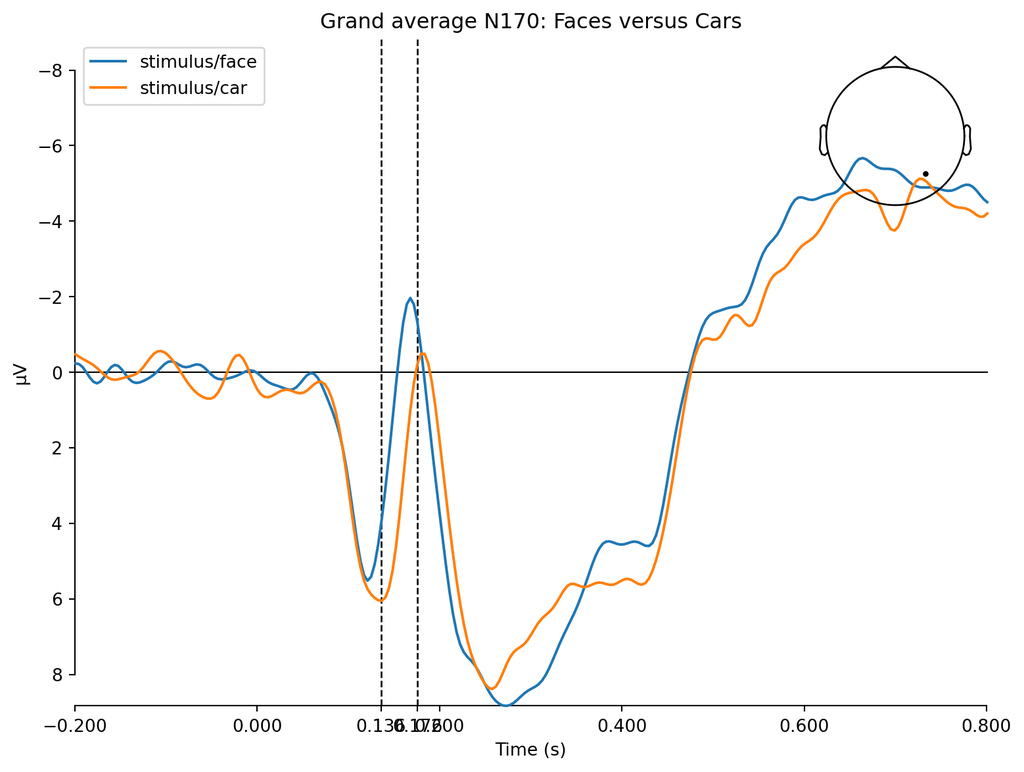

```python
selected_electrode = "PO8"
plot_title = "Grand average N170: Faces versus Cars"
analysis_window_start = 0.136
analysis_window_end = 0.176

plot_evokeds(grand_avs, picks = selected_electrode, invert_y = True, title = plot_title, vlines = [analysis_window_start, analysis_window_end])
```

Figure 1 visualises the N170 grand average ERPs for face and car stimuli measured at PO8 using the adjusted measurement window of 136-176 ms. Within this time window, both conditions begin at positive amplitudes before crossing baseline, after which both conditions show a sharp negative-going deflection. The face condition shows a slightly larger and earlier negative peak than the car condition, whose peak occurs slightly outside the end of the 176 ms time window.

Before the time window, both conditions fluctuate before showing a positive-going deflection, with the face condition peaking sooner than the car condition, whose positive peak occurs near the beginning of the time window. The face condition then returns toward baseline earlier and more sharply than the car condition, with both waveforms becoming increasingly separated.

Following their negative peaks inside the time window for faces and slightly outside the time window for cars, both waveforms follow similar positive-going deflections, passing baseline, and continuing to a large positive peak, before gradually fluctuating and returning toward baseline and later crossing into negative voltages. Both waveforms continued fluctuating in later portions of the epoch recording; however, these occurred beyond the N170 time window and were not examined further.

## Discussion and reflection

The present study broadly replicated Kappenman et al.’s (2021) ERP grand-average findings, with the face condition producing a slightly larger and earlier negative N170 peak than the car condition at PO8. Kappenman et al. (2021) similarly reported a larger and earlier N170 for faces than cars, most pronounced over the right inferotemporal region.

Kappenman et al. (2021) corrected event codes for LCD delay, while the present analysis shifted the N170 window by 26 ms from 110-150 ms to 136-176 ms. Within this adjusted window, the face condition peaked, while the car condition peaked slightly outside the upper boundary, reflecting the latency differences between conditions, consistent with Kappenman et al. (2021), and wider literature indicating larger negative N170 responses to faces than non-face objects (Bentin et al. 1996; Eimer 2011).

Applying and modifying the EEG pipeline for N170 analysis helped develop my understanding of preprocessing, epoching, and averaging, and their influence on the final grand average and its interpretation. Adapting small methodological decisions, from exclusion criteria and filter cutoffs to shifting measurement windows, further demonstrated their impact on analysis. Learning how to transform raw EEG data into finalised grand-average ERPs improved my comprehension of EEG analysis and interpretation, providing knowledge transferable to future research. Rather than relying solely on another study’s discussion and conclusions, applying the analysis myself deepened my understanding of how such conclusions are reached.

## Statement of use of Generative AI

AI (ChatGPT; OpenAI) was used to support the development of this report, primarily for troubleshooting and understanding Python/Quarto/Markdown/YAML code, checking that EndNote’s reference output matches the .bib file, alongside understanding and learning how to reference with Quarto using Week 10 course material, as I was absent that week. Minor proofreading and grammar correction were also used; however majority of suggestions were rejected, rather opting to use word’s inbuilt processes. All code used reflects the continually developed EEG pipeline created in class, rather than code generated by AI.

## References

Bentin, S., T. Allison, A. Puce, E. Perez, and G. McCarthy. 1996. “Electrophysiological Studies of Face Perception in Humans.” Journal Article. *Journal of Cognitive Neuroscience* 8 (6): 551–65. https://doi.org/10.1162/jocn.1996.8.6.551.

Bötzel, K., S. Schulze, and S. R. Stodieck. 1995. “Scalp Topography and Analysis of Intracranial Sources of Face-Evoked Potentials.” Journal Article. *Experimental Brain Research* 104 (1): 135–43. https://doi.org/10.1007/BF00229863.

Cashon, C. H., and N. A. Holt. 2015. “Developmental Origins of the Face Inversion Effect.” Journal Article. *Advances in Child Development and Behavior* 48: 117–50. https://doi.org/10.1016/bs.acdb.2014.11.008.

Deng, Jia-Rui, Xiao-Tong Zhang, Nan Wang, Jie-Ping Chen, and Zhuo-Ming Chen. 2025. “Atypical Face Recognition and Hemispheric Lateralization in Autism Spectrum Disorder with N170 Signatures: A Systematic Review and Meta-Analysis.” Journal Article. *Review Journal of Autism and Developmental Disorders*, ahead of print. https://doi.org/10.1007/s40489-025-00502-4.

Eimer, Martin. 2011. “The Face-Sensitive N170 Component of the Event-Related Brain Potential.” Book Section to *The Oxford Handbook of Face Perception*, edited by A. J. Calder, G. Rhodes, M. H. Johnson, and J. V. Haxby. Oxford University Press. https://doi.org/10.1093/oxfordhb/9780199559053.013.0017.

Gao, C., S. Conte, J. E. Richards, W. Xie, and T. Hanayik. 2019. “The Neural Sources of N170: Understanding Timing of Activation in Face-Selective Areas.” Journal Article. *Psychophysiology* 56 (6): e13336. https://doi.org/10.1111/psyp.13336.

Huang, W., Y. Wang, X. Chen, S. Liu, Z. Qu, and Y. Ding. 2026. “The N170 Is Linked to Configural Face Processing: Evidence from the N170 Adaptation Effect for Upright Faces.” Journal Article. *Psychophysiology* 63 (1): e70238. https://doi.org/10.1111/psyp.70238.

Kappenman, Emily S., Jaclyn L. Farrens, Wendy Zhang, Andrew X. Stewart, and Steven J. Luck. 2021. “ERP CORE: An Open Resource for Human Event-Related Potential Research.” *NeuroImage* 225 (January): 117465. https://doi.org/10.1016/j.neuroimage.2020.117465.

Kropotov, Juri D. 2016. *Functional Neuromarkers for Psychiatry: Applications for Diagnosis and Treatment*. Book. Functional Neuromarkers for Psychiatry: Applications for Diagnosis and Treatment. Elsevier Academic Press.

Pascalis, Olivier, Mathilde Fort, Jonathan E. Prunty, and David J. Kelly. 2020. “Face Processing.” Book Section to *Encyclopedia of Infant and Early Childhood Development*. https://doi.org/10.1016/b978-0-12-809324-5.23264-1.

Prieto, E. A., S. Caharel, R. Henson, and B. Rossion. 2011. “Early (n170/m170) Face-Sensitivity Despite Right Lateral Occipital Brain Damage in Acquired Prosopagnosia.” Journal Article. *Frontiers in Human Neuroscience* 5: 138. https://doi.org/10.3389/fnhum.2011.00138.

Rossion, B., J. F. Delvenne, D. Debatisse, et al. 1999. “Spatio-Temporal Localization of the Face Inversion Effect: An Event-Related Potentials Study.” Journal Article. *Biological Psychology* 50 (3): 173–89. https://doi.org/10.1016/s0301-0511(99)00013-7.

Rossion, Bruno, and Stéphanie Caharel. 2011. “ERP Evidence for the Speed of Face Categorization in the Human Brain: Disentangling the Contribution of Low-Level Visual Cues from Face Perception.” Journal Article. *Vision Research* 51 (12): 1297–311. https://doi.org/10.1016/j.visres.2011.04.003.

Sadeh, B., and G. Yovel. 2010. “Why Is the N170 Enhanced for Inverted Faces? An ERP Competition Experiment.” Journal Article. *NeuroImage* 53 (2): 782–89. https://doi.org/10.1016/j.neuroimage.2010.06.029.

Srebro, R. 1985. “Localization of Cortical Activity Associated with Visual Recognition in Humans.” Journal Article. *The Journal of Physiology* 360: 247–59. https://doi.org/10.1113/jphysiol.1985.sp015615.

Vékony, Teodóra, and Gábor Csifcsák. 2017. *Hemispheric Lateralization of the N170 Inversion Effect for Faces and Words*. Conference Paper.